# Figure 3: RIG-I-only vs STAT-only signatures in nasal swabs of SARS-CoV-2 patients (scRNA-Seq)

Carlos Ramirez

2026-10-27 17:05:22

This markdown reproduces the panels of **Figure 3**. We project the RIG-I-only and STAT-only (IFN-only) signatures, derived from the A549 bulk model in Figure 1, onto the single-cell RNA-Seq data of nasal swabs from SARS-CoV-2 positive and negative children and adults published by [Loske et al. 2021, Nat. Biotechnol.](https://www.nature.com/articles/s41587-021-01037-9). Every cell is scored with both signatures (Seurat `AddModuleScore`), and cells are classified into two quadrants of the RIG-I-only vs STAT-only score plane using thresholds derived from SARS-CoV-2 negative donors (99.959 % quantile of the RIG-I-only score and 99.99 % quantile of the STAT-only score of all cells of SARS-CoV-2 negative donors):

- **Quadrant I**: RIG-I-only score above threshold and STAT-only score below threshold (cells with direct RIG-I activity but no IFN-receptor signalling).
- **Quadrant II**: STAT-only score above threshold and RIG-I-only score below threshold (bystander cells responding to secreted IFN).

Panels produced (all saved in `figures/figure_03/`):

| Panel file | Content |
| --- | --- |
| `gathering_loske_dataset.pdf` | RIG-I-only vs STAT-only scores of all cells, split by SARS-CoV-2 status and coloured by quadrant |
| `barplots_cell_types_qII.pdf` | Cell-type composition of quadrant I, quadrant II and all cells of SARS-CoV-2 positive donors, with the Fisher-test (BH-adjusted) p-value for enrichment of each cell type in quadrant I |
| `scatterplot_rig_vs_stat_selected_cell_types.pdf` | RIG-I-only vs STAT-only scores of cells carrying SARS-CoV-2 transcripts in selected cell types, coloured by viral load |
| `neutrophils_features_scov2pos.pdf` | RIG-I-only vs STAT-only scores of neutrophils carrying SARS-CoV-2 transcripts coloured by viral load, age group and IFNL1 expression |

The code was taken from the original analysis script `/media/ag-cherrmann/cramirez/interferon_model/scripts/R/july_2026/03_scRNASeq_projections_loske.Rmd` (which wrote these panels to `figures/2026_May/` on 2026-10-01), except for the cell-type barplot (`barplots_cell_types_qII.pdf`), which was produced on 2026-05-18 by an earlier version of `/media/ag-cherrmann/cramirez/interferon_model/scripts/R/may_2026/03_scRNASeq_projections_loske.Rmd` (see the section *Cell-type composition of the quadrants* for details). Only the code needed for these panels was kept; plotting code, PDF sizes and aesthetics are unchanged.

The neutrophil subset defined at the end of this markdown (SARS-CoV-2 transcript-positive neutrophils used for the children vs adults comparison) is saved to `analysis/figure_03/` and is the input of `supplementary_figure_03.Rmd` (volcano plot and GSEA), so **this markdown has to be run before `supplementary_figure_03.Rmd`**.

# Input data

| Input | Absolute path / source |
| --- | --- |
| Processed Seurat object of the nasal-swab scRNA-Seq data (raw counts, normalised data, UMAP and cell annotation as published by the authors; file `210716_figshare_upload_ag_lehmann.rds` downloaded fro… | `/media/bq-storage/ag-cherrmann/cramirez/data/loske_2021/210716_figshare_upload_ag_lehmann.rds` |
| Cell metadata used (columns of the Seurat object above, as provided by Loske et al.) | `detailed_clusters` (cell type), `covid` (SARS-CoV-2 status of the donor: `pos` / `neg`), `covid_kid1` (status x age group: `pos_adult`, `pos_children`, `neg_adult`, `neg_children`), `dps` (days post … |
| Viral load per cell | `SARS-CoV-2-p` expression (normalised data of the Seurat object above) |
| RIG-I-only / STAT-only signatures (written by `figure_01.Rmd`) | `/media/bq-storage/ag-cherrmann/cramirez/decoupling_rigi_ifn/analysis/figure_01/rigi_vs_stat_only_signatures.rds` (`path2signs` in `settings.R`) |
| Shared settings (paths, colours) | `/media/bq-storage/ag-cherrmann/cramirez/decoupling_rigi_ifn/scripts/R/settings.R` |

No MSigDB gene sets are used for the panels of this figure.

```r
library(dplyr)
library(ggplot2)
library(Seurat)
library(gridExtra)
library(RColorBrewer)
library(colorspace)

source("/media/bq-storage/ag-cherrmann/cramirez/decoupling_rigi_ifn/scripts/R/settings.R")
```

## Initial settings

Output folders of this section (`figures/figure_03/` and `analysis/figure_03/` in the repository).

```r
dirs <- section_dirs("figure_03")
path2figures <- dirs$figures
path2analysis <- dirs$analysis
```

## Loading the data from Loske et al. 2021

Processed Seurat object as published by the authors on figshare. The object already contains normalised data and the cell annotation, so no further processing is needed.

```r
path2loske <- '/media/bq-storage/ag-cherrmann/cramirez/data/loske_2021/210716_figshare_upload_ag_lehmann.rds'
seurat <- readRDS(path2loske)
seurat
```

```
## An object of class Seurat
## 26698 features across 268745 samples within 1 assay
## Active assay: RNA (26698 features, 0 variable features)
##  2 layers present: counts, data
##  1 dimensional reduction calculated: umap
```

Overview of the metadata columns used in this figure and confirmation that the viral transcripts are features of the object.

```r
table(seurat$covid, useNA = 'ifany')
```

```
##
##    neg    pos
## 114296 154449
```

```r
table(seurat$covid_kid1, useNA = 'ifany')
```

```
##
## neg_children    neg_adult pos_children    pos_adult
##        51595        62701       102949        51500
```

```r
table(seurat$dps, useNA = 'ifany')
```

```
##
##           0           1          10          11          12           2
##        7688        5683        5286        9856        1583       23115
##           3           4           5           6           7           8
##       26802       11323       18775       18682        3509        4279
##           9    negative no symptoms
##        7607      114296       10261
```

```r
table(seurat$detailed_clusters, useNA = 'ifany')
```

```
##
##            Club          Goblet        Sec_diff        Ciliated Cil_acute_phase
##           14023           34088           11845           29194           19735
##        Cil_diff           Basal           FOXN4        Ionocyte        Squamous
##           10057            5778            2322            2248            5281
##      Epi_lowRNA          lowRNA          B_cell     Plasma_cell            CTL1
##           19659            5195            3130            2106            8704
##            CTL2       IL17A_CD4       IL17A_CD8          CD8_Tm             DNT
##            8439            3649            5150            3943            7233
##            Treg            ag_T             p_T           p_NKT              NK
##            2517            4225            3159             292            2404
##            moMa            nrMa             rMa             pDC       CD11c_mDC
##            7555            2948           14597            2399            2192
##             mDC      Neutrophil     MC_Basophil
##            4757           19476             445
```

```r
c('SARS-CoV-2-p', 'SARS-CoV-2-m') %in% rownames(seurat)
```

```
## [1] TRUE TRUE
```

## Loading signatures

RIG-I-only and STAT-only signatures defined in Figure 1. As in the original analysis, interferon genes (IFNB / IFNL) are removed from the signatures before scoring, and the list is reordered as (`stat_only`, `rigi_only`), so that `AddModuleScore` names the scores `stat_only1` and `rigi_only2`.

```r
signatures <- readRDS(path2signs)
signatures <- lapply(signatures,
                     function(genes){
                             genes[!grepl('IFNB|IFNL', genes)]
})
signatures <- signatures[c(2,1)]
str(signatures)
```

```
## List of 2
##  $ stat_only: chr [1:99] "PNPT1" "TRIM5" "CSF1" "ZNF711" ...
##  $ rigi_only: chr [1:94] "EGR4" "CXCL11" "FOSB" "EGR2" ...
```

## Scoring cells

Module scores of both signatures for every cell (`AddModuleScore` uses a fixed seed by default, so scores are reproducible).

```r
seurat <- AddModuleScore(seurat,
                         features = signatures,
                         name = names(signatures))
seurat@meta.data %>% colnames
```

```
##  [1] "nCount_RNA"        "nFeature_RNA"      "gender"
##  [4] "covid"             "covid_kid1"        "paper_age"
##  [7] "WHO_class"         "dps"               "percent.mt"
## [10] "detailed_clusters" "Patient_ID"        "stat_only1"
## [13] "rigi_only2"
```

## Selected cell types (panel `scatterplot_rig_vs_stat_selected_cell_types.pdf`)

RIG-I-only vs STAT-only scores of cells with SARS-CoV-2 (+) strand transcripts (`SARS-CoV-2-p > 0`) in nine selected cell types, coloured by the viral load. Donors at 10-12 days post symptoms are excluded.

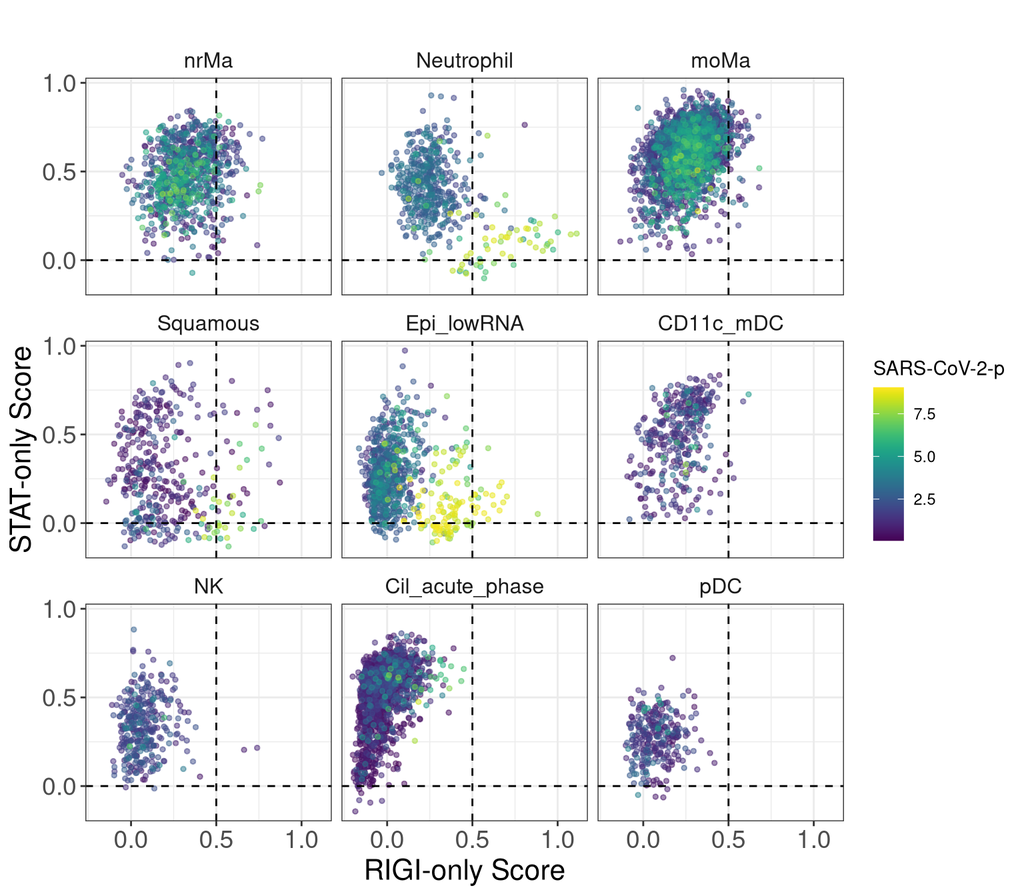

```r
df_signatures <- FetchData(seurat, c('stat_only1',
                                     'rigi_only2',
                                     'covid',
                                     'dps',
                                     'detailed_clusters',
                                     'SARS-CoV-2-p',
                                     'SARS-CoV-2-m')) %>%
        dplyr::filter(!dps %in% c('10', '11', '12')) %>%
        dplyr::mutate(dps = factor(dps, sort(unique(dps))))


selected_cells <- c("nrMa",
                "Neutrophil",
                "moMa",
                "Squamous",
                "Epi_lowRNA",
                "CD11c_mDC",
                "NK",
                "Cil_acute_phase",
                "pDC")
p_all <- df_signatures %>%
        dplyr::filter(`SARS-CoV-2-p` > 0) %>%
        arrange(`SARS-CoV-2-p`) %>%
        filter(detailed_clusters %in% selected_cells) %>%
        mutate(detailed_clusters = factor(detailed_clusters,
                                          levels = selected_cells)) %>%
ggplot(aes(x = rigi_only2,
                          y = stat_only1,
                          colour = `SARS-CoV-2-p`)) +
  geom_point(alpha = 0.5, size = 1) +
  geom_vline(xintercept = 0.5, linetype = 'dashed') +
  geom_hline(yintercept = 0.0, linetype = 'dashed') +
  facet_wrap(  ~ detailed_clusters) +
  scale_x_continuous(breaks = scales::pretty_breaks(n = 3)) +
  scale_y_continuous(breaks = scales::pretty_breaks(n = 3)) +
  theme_bw() +
  theme(
    axis.text = element_text(size = 14),
    axis.title = element_text(size = 16),
    strip.text = element_text(size = 12),
    strip.background = element_blank()
  ) +
  labs(
    x = "RIGI-only Score",
    y = "STAT-only Score",
    title = ""
  ) + viridis::scale_color_viridis()


p_all
```

```r
pdf(paste0(path2figures,
           "/scatterplot_rig_vs_stat_selected_cell_types.pdf"),
    width=8, height=7)
p_all
dev.off()
```

## Virtual gathering (panel `gathering_loske_dataset.pdf`)

Quadrant thresholds are computed from cells of SARS-CoV-2 negative donors (99.99 % quantile of `stat_only1`, 99.959 % quantile of `rigi_only2`). Quadrant I: `stat_only1 <= stat_th & rigi_only2 >= rigi_th`; quadrant II: `stat_only1 >= stat_th & rigi_only2 <= rigi_th`; all other cells are `NA` (grey). All cells are plotted, split by SARS-CoV-2 status of the donor.

```r
md <- FetchData(seurat,
                vars = c(colnames(seurat@meta.data),
                         'SARS-CoV-2-p'))

cols <- brewer.pal(4, "Set2")[2:4]
names(cols) <- c("I", "II")

stat_th <- quantile(subset(md, covid == 'neg')$stat_only1, 0.9999)
stat_th
```

```
##    99.99%
## 0.6079971
```

```r
rigi_th <- quantile(subset(md, covid == 'neg')$rigi_only2, 0.99959)
rigi_th
```

```
##   99.959%
## 0.5582593
```

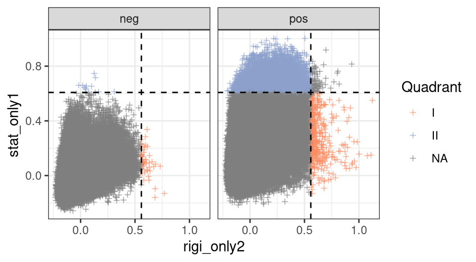

```r
md <-  md %>%
  mutate(
    quadrant = case_when(
      stat_only1 <= stat_th & rigi_only2 >= rigi_th ~ "I",
      stat_only1 >= stat_th & rigi_only2 <= rigi_th   ~ "II",
      FALSE ~ "III"
    )
  )
gathering_loske <- md %>%  ggplot(aes(x = rigi_only2, y = stat_only1, color = quadrant)) +
  geom_point(alpha = 0.6, size = 1, shape = 3) +
  geom_hline(yintercept = stat_th, linetype = 'dashed') +
  geom_vline(xintercept = rigi_th, linetype = 'dashed') +
  theme_bw() +
        facet_wrap(~covid) +
        scale_colour_manual(values = cols) +
  labs(
    x = "rigi_only2",
    y = "stat_only1",
    color = "Quadrant"
  ) +
        scale_x_continuous(breaks = c(0, 0.5, 1.0))

gathering_loske
```

```r
pdf(paste0(path2figures,
           '/gathering_loske_dataset.pdf'),
    width=5, height=2.75)
gathering_loske
dev.off()
```

Number of cells per quadrant and SARS-CoV-2 status.

```r
table(md$covid, md$quadrant, useNA = 'ifany')
```

```
##
##            I     II   <NA>
##   neg     47     12 114237
##   pos    363   7014 147072
```

## Cell-type composition of the quadrants (panel `barplots_cell_types_qII.pdf`)

**Provenance of this panel.** The figure panel `/media/ag-cherrmann/cramirez/interferon_model/figures/2026_May/barplots_cell_types_qII.pdf` (2026-05-18) was produced by an earlier version of `/media/ag-cherrmann/cramirez/interferon_model/scripts/R/may_2026/03_scRNASeq_projections_loske.Rmd`. The current version of that script contains the same plotting code but labels the “Total” column with a string pasting the quadrant I and quadrant II FDRs from a separate test (`results_joined`, computed in a later chunk) and saves the plot as `barplots_cell_types_fdr.pdf` (2026-06-24). Comparing both PDFs, the bars and percentages are identical, but the qII panel shows labels of the form `adj.p = 4e-54`, i.e. the `p_label` column built in this very chunk from the BH-adjusted Fisher-test p-value of enrichment of each cell type in quadrant I (`padj_I`). Therefore, the code below is the current `may_2026` code with the label of the p-value text layer set to `p_label` (data `plot_df`) instead of the FDR string of `plot_df_fdr`; everything else (bars, colours, sizes, the 7 x 3 inch PDF) is unchanged. The output is saved under the name of the figure panel, `barplots_cell_types_qII.pdf`.

```r
# =========================================================
# 1. Compute proportions
# =========================================================

## Preparing the data
# keep only relevant columns
df <- md %>%
  filter(covid == "pos") %>%
  select(detailed_clusters, quadrant)

# total number of cells
n_total <- nrow(df)

prop_total <- df %>%
  count(detailed_clusters) %>%
  mutate(
    group = "Total",
    proportion = n / sum(n)
  )

prop_I <- df %>%
  filter(quadrant == "I") %>%
  count(detailed_clusters) %>%
  mutate(
    group = "I",
    proportion = n / sum(n)
  )

prop_II <- df %>%
  filter(quadrant == "II") %>%
  count(detailed_clusters) %>%
  mutate(
    group = "II",
    proportion = n / sum(n)
  )

props <- bind_rows(
  prop_total,
  prop_I,
  prop_II
)

# =========================================================
# 2. Keep only clusters present in quadrant I
# =========================================================


clusters_keep <- prop_I %>%
  filter(proportion > 0) %>%
  pull(detailed_clusters)

props <- props %>%
  filter(detailed_clusters %in% clusters_keep)

# =========================================================
# 3. Fisher enrichment tests
# =========================================================

df_test <- df

clusters <- unique(props$detailed_clusters)

enrichment_results <- lapply(clusters, function(cl){

  # -------------------------------------------------------
  # Fisher test for Quadrant I enrichment
  # -------------------------------------------------------

  tab_I <- matrix(c(

    # cluster in I
    sum(
      df_test$detailed_clusters == cl &
        df_test$quadrant == "I",
      na.rm = TRUE
    ),

    # other clusters in I
    sum(
      df_test$detailed_clusters != cl &
        df_test$quadrant == "I",
      na.rm = TRUE
    ),

    # cluster not in I
    sum(
      df_test$detailed_clusters == cl &
        df_test$quadrant != "I",
      na.rm = TRUE
    ),

    # other clusters not in I
    sum(
      df_test$detailed_clusters != cl &
        df_test$quadrant != "I",
      na.rm = TRUE
    )

  ),
  nrow = 2,
  byrow = TRUE)

  test_I <- fisher.test(tab_I)

  data.frame(
    detailed_clusters = cl,
    p_I = test_I$p.value,
    OR_I = test_I$estimate
  )

}) %>%
  bind_rows()

# ---------------------------------------------------------
# Adjust p-values
# ---------------------------------------------------------

enrichment_results <- enrichment_results %>%
  mutate(
    padj_I = p.adjust(p_I, method = "BH")
  )

# =========================================================
# 4. Merge
# =========================================================

plot_df <- props %>%
  left_join(
    enrichment_results,
    by = "detailed_clusters"
  )

# =========================================================
# 5. Labels
# =========================================================

plot_df <- plot_df %>%
  mutate(

    proportion_pct = round(
      proportion * 100,
      1
    ),

    prop_label = paste0(
      proportion_pct,
      "%"
    ),

    p_label = paste0(
      "adj.p = ",
      signif(padj_I, 2)
    )
  )

# =========================================================
# 6. Order clusters
# =========================================================

cluster_order <- prop_I %>%
  arrange(desc(proportion)) %>%
  pull(detailed_clusters)

plot_df$detailed_clusters <- factor(
  plot_df$detailed_clusters,
  levels = rev(cluster_order)
)

# =========================================================
# 7. TRUE 0-100% SCALE
# =========================================================
# Bars now represent actual percentages
# instead of scaling to group maxima
# =========================================================

plot_df <- plot_df %>%
  mutate(
    scaled_prop = proportion
  )

# =========================================================
# 8. Palette
# =========================================================

n_clusters <- length(
  unique(plot_df$detailed_clusters)
)

pal <- qualitative_hcl(
  n_clusters,
  palette = "Dark 3"
)

names(pal) <- levels(
  plot_df$detailed_clusters
)

# =========================================================
# 9. Plot
# =========================================================

barplots_cell_types <- ggplot(
  plot_df,
  aes(
    x = group,
    y = detailed_clusters
  )
) +

  # -------------------------------------------------------
  # background boxes (100% width)
  # -------------------------------------------------------

  geom_rect(
    aes(
      xmin = as.numeric(factor(group)) - 0.40,
      xmax = as.numeric(factor(group)) + 0.40,

      ymin = as.numeric(detailed_clusters) - 0.33,
      ymax = as.numeric(detailed_clusters) + 0.33
    ),
    fill = "white",
    color = "black",
    inherit.aes = FALSE
  ) +

  # -------------------------------------------------------
  # loading bars
  # -------------------------------------------------------

  geom_rect(
    aes(

      xmin = as.numeric(factor(group)) - 0.40,

      xmax =
        (as.numeric(factor(group)) - 0.40) +
        scaled_prop * 0.80,

      ymin = as.numeric(detailed_clusters) - 0.22,
      ymax = as.numeric(detailed_clusters) + 0.22,

      fill = detailed_clusters
    ),
    color = NA
  ) +

  # -------------------------------------------------------
  # proportion labels
  # -------------------------------------------------------

  geom_text(
    data = subset(plot_df, group == "I"),
    aes(label = prop_label),
    x = 0.58,
    size = 3,
    hjust = 1
  ) +

  geom_text(
    data = subset(plot_df, group == "II"),
    aes(label = prop_label),
    x = 1.58,
    size = 3,
    hjust = 1
  ) +

  geom_text(
    data = subset(plot_df, group == "Total"),
    aes(label = prop_label),
    x = 2.58,
    size = 3,
    hjust = 1
  ) +

  # -------------------------------------------------------
  # p-value labels (quadrant I enrichment, BH-adjusted)
  # -------------------------------------------------------

  geom_text(
    data = subset(plot_df, group == "Total"),
    aes(label = p_label),
    x = 3.08,
    size = 2.6,
    hjust = 0
  ) +

  # -------------------------------------------------------
  # colors
  # -------------------------------------------------------

  scale_fill_manual(values = pal) +

  # -------------------------------------------------------
  # theme
  # -------------------------------------------------------

  theme_minimal(base_size = 12) +

  theme(
    panel.grid = element_blank(),

    axis.title = element_blank(),

    legend.position = "none",

    axis.text.x = element_text(
      face = "bold",
      size = 12
    ),

    axis.text.y = element_text(
      face = "bold",
      size = 11
    ),

    panel.background = element_rect(
      fill = "grey96",
      color = NA
    )
  )



pdf(paste0(path2figures,
           '/barplots_cell_types_qII.pdf'),
    width=7.0, height=3.0)
barplots_cell_types
dev.off()
```

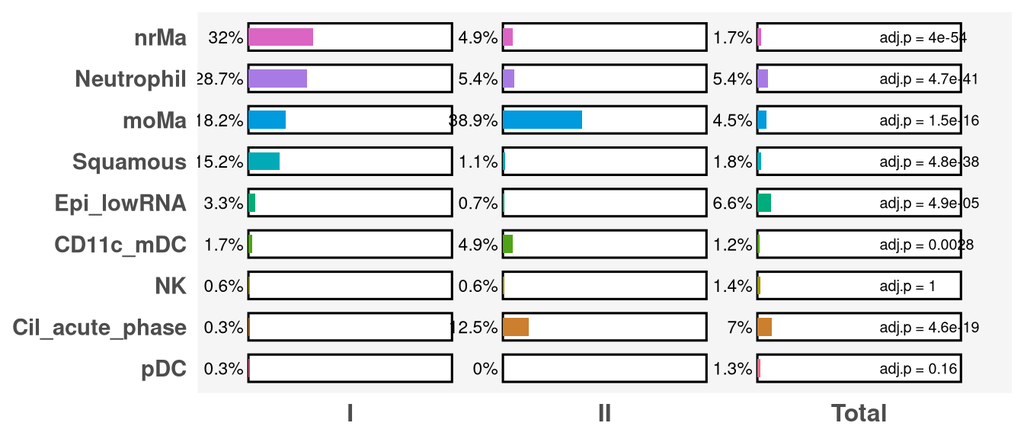

```r
barplots_cell_types
```

The proportions and the Fisher-test results behind the panel are saved to `analysis/figure_03/barplots_cell_types_qII_data.xlsx`.

```r
writexl::write_xlsx(
        plot_df %>%
                mutate(detailed_clusters = as.character(detailed_clusters)),
        path = paste0(path2analysis, "/barplots_cell_types_qII_data.xlsx")
)
```

## Neutrophils of SARS-CoV-2 positive donors (panel `neutrophils_features_scov2pos.pdf`)

Neutrophils carrying SARS-CoV-2 transcripts (`SARS-CoV-2-p > 0` or `SARS-CoV-2-m > 0`) from SARS-CoV-2 positive donors (10-12 days post symptoms excluded). RIG-I-only vs STAT-only scores coloured by (left) viral load (`SARS-CoV-2-p`), (middle) age group (`covid_kid1`) and (right) IFNL1 expression.

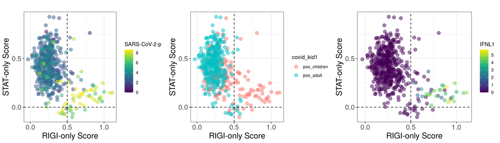

```r
df_signatures <- FetchData(seurat, c('stat_only1',
                                     'rigi_only2',
                                     'covid',
                                     'dps',
                                     'detailed_clusters',
                                     'SARS-CoV-2-p',
                                     'SARS-CoV-2-m',
                                     'covid_kid1',
                                     'OASL',
                                     'IFNL1')) %>%
        dplyr::filter(!dps %in% c('10', '11', '12')) %>%
        dplyr::mutate(dps = factor(dps, sort(unique(dps))))

neu_sarscov2 <- df_signatures %>%
        dplyr::filter(`SARS-CoV-2-p` > 0 |
                              `SARS-CoV-2-m` > 0) %>%
        dplyr::filter( ! covid_kid1 %in% c('neg_adult',
                                        'neg_children')) %>%
        dplyr::filter(detailed_clusters %in% c(
                                        'Neutrophil') ) %>%
        arrange(`SARS-CoV-2-p`) %>%
 ggplot(aes(x = rigi_only2,
                          y = stat_only1,
                          colour = `SARS-CoV-2-p`)) +
  geom_point(alpha = 0.5, size = 3) +
        viridis::scale_color_viridis() +
  geom_vline(xintercept = 0.5, linetype = 'dashed') +
  geom_hline(yintercept = 0.0, linetype = 'dashed') +
  scale_x_continuous(breaks = scales::pretty_breaks(n = 3)) +
  scale_y_continuous(breaks = scales::pretty_breaks(n = 3)) +
  theme_bw() +
  theme(
    axis.text = element_text(size = 14),
    axis.title = element_text(size = 16),
    strip.text = element_text(size = 12),
    strip.background = element_blank()
  ) +
  labs(
    x = "RIGI-only Score",
    y = "STAT-only Score",
    title = ""
  )


neu_ifnl <- df_signatures %>%
        dplyr::filter(`SARS-CoV-2-p` > 0 |
                              `SARS-CoV-2-m` > 0) %>%
        dplyr::filter( ! covid_kid1 %in% c('neg_adult',
                                        'neg_children')) %>%
        dplyr::filter(detailed_clusters %in% c(
                                        'Neutrophil') ) %>%
        arrange(OASL) %>%
 ggplot(aes(x = rigi_only2,
                          y = stat_only1,
                          colour = IFNL1)) +
  geom_point(alpha = 0.5, size = 3) +
        viridis::scale_color_viridis() +
  geom_vline(xintercept = 0.5, linetype = 'dashed') +
  geom_hline(yintercept = 0.0, linetype = 'dashed') +
  scale_x_continuous(breaks = scales::pretty_breaks(n = 3)) +
  scale_y_continuous(breaks = scales::pretty_breaks(n = 3)) +
  theme_bw() +
  theme(
    axis.text = element_text(size = 14),
    axis.title = element_text(size = 16),
    strip.text = element_text(size = 12),
    strip.background = element_blank()
  ) +
  labs(
    x = "RIGI-only Score",
    y = "STAT-only Score",
    title = ""
  )

neu_stage <- df_signatures %>%
        dplyr::filter(`SARS-CoV-2-p` > 0 |
                              `SARS-CoV-2-m` > 0) %>%
        dplyr::filter( ! covid_kid1 %in% c('neg_adult',
                                        'neg_children')) %>%
        dplyr::filter(detailed_clusters %in% c(
                                        'Neutrophil') ) %>%
 ggplot(aes(x = rigi_only2,
                          y = stat_only1,
                          colour = covid_kid1)) +
  geom_point(alpha = 0.5, size = 3) +
  geom_vline(xintercept = 0.5, linetype = 'dashed') +
  geom_hline(yintercept = 0.0, linetype = 'dashed') +
  scale_x_continuous(breaks = scales::pretty_breaks(n = 3)) +
  scale_y_continuous(breaks = scales::pretty_breaks(n = 3)) +
  theme_bw() +
  theme(
    axis.text = element_text(size = 14),
    axis.title = element_text(size = 16),
    strip.text = element_text(size = 12),
    strip.background = element_blank()
  ) +
  labs(
    x = "RIGI-only Score",
    y = "STAT-only Score",
    title = ""
  )

gridExtra::grid.arrange(neu_sarscov2,
                        neu_stage,
                        neu_ifnl, ncol = 3)
```

```r
pdf(paste0(path2figures,
           '/neutrophils_features_scov2pos.pdf'),
    height=4.0, width=14)
gridExtra::grid.arrange(neu_sarscov2,
                        neu_stage,
                        neu_ifnl, ncol = 3)
dev.off()
```

## Neutrophil subset for the children vs adults comparison (input of Supplementary Figure 3)

Same neutrophils as above, excluding children neutrophils with low RIG-I-only score (`rigi_only2 < 0.5`) and all neutrophils with `stat_only1 >= 0.25`, as in the original analysis. This subset is the input of the differential expression analysis (children vs adults) in `supplementary_figure_03.Rmd`, and is saved to `analysis/figure_03/seurat_neutrophils_scov2pos_children_vs_adults.rds`.

```r
selected_cells <- df_signatures %>%
        dplyr::filter(`SARS-CoV-2-p` > 0 |
                              `SARS-CoV-2-m` > 0) %>%
        dplyr::filter( ! covid_kid1 %in% c('neg_adult',
                                        'neg_children')) %>%
        dplyr::filter(detailed_clusters %in% c(
                                        'Neutrophil') )  %>%
        dplyr::filter( ! ( rigi_only2 < 0.5 &
                                  covid_kid1 == 'pos_children' ) ) %>%
        rownames()


seurat_subset <- seurat[, selected_cells]
seurat_subset <- subset(seurat_subset, stat_only1 < 0.25)

seurat_subset$covid_kid1 %>% table
```

```
## .
## neg_children    neg_adult pos_children    pos_adult
##            0            0           38           41
```

```r
saveRDS(seurat_subset,
        file = paste0(path2analysis,
                      "/seurat_neutrophils_scov2pos_children_vs_adults.rds"))
```